# Structural Divergence Analysis

María Laura Marcos, Julian Echave

25 de julio de 2016

# Introduction

We study the evolutionary divergence of proteins using the LFENM and compare with experimental data.

We use the ANM Elastic Network Model with `R0 =` 10 for the globins family. We use as reference for the ENM the protein with pdb code 1a6m. The globins family consists of the following proteins:

```
##  [1] "1bina" "1lh1"  "1hlm"  "1hlb"  "2mm1"  "1pmba" "1ymb"  "1mbs"
##  [9] "1emy"  "1lht"  "1myt"  "2pghb" "2hhbb" "1hdab" "2mhbb" "1hdsb"
## [17] "1fdhg" "1spgb" "1hbhb" "1outb" "1spga" "1pbxa" "1hdaa" "2hhba"
## [25] "2mhba" "2pgha" "1hdsa" "1outa" "2lhb"  "1itha" "1ecd"  "1a4fa"
## [33] "1a4fb" "1a9we" "1hbra" "1cg5a" "1cg5b"
```

| MSD.exp | MSD.mut | MSD.strong |
| --- | --- | --- |
| 1.0238 | 1.0082 | 1.0082 |

# Structural divergence along sites

Here we study how structural divergence varies from site to site. We will compare simulated data and empirical data.

### Mean z.RSD vs site

To measure structural divergence we use z.RSD profiles, which are the best (most similar distributions and profiles w.r.t experimental).

The following plot compares the mean z.RSD profiles, including standard errors (with .999 confidence level for the mean) *Warning: the effective number of data should be smaller than the actual data, especially for the experimental dataset because of several factors, including smoothing of the profiles, phylogenetic relationships, etc. We need to deal with this for quantitative analysis. Probably we’ll need to use bootstrapping to calculate standard errors non-parametrically*

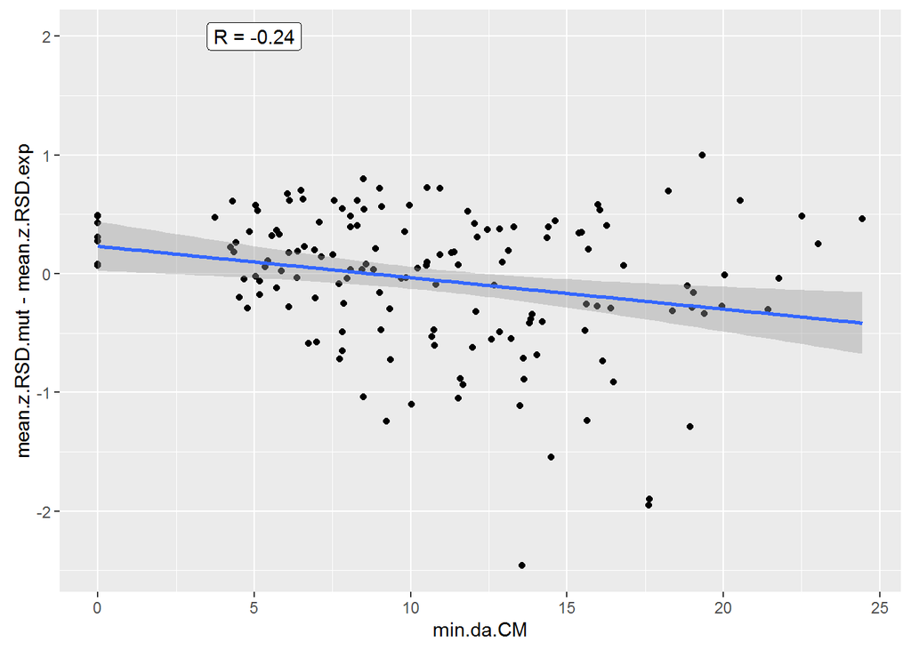

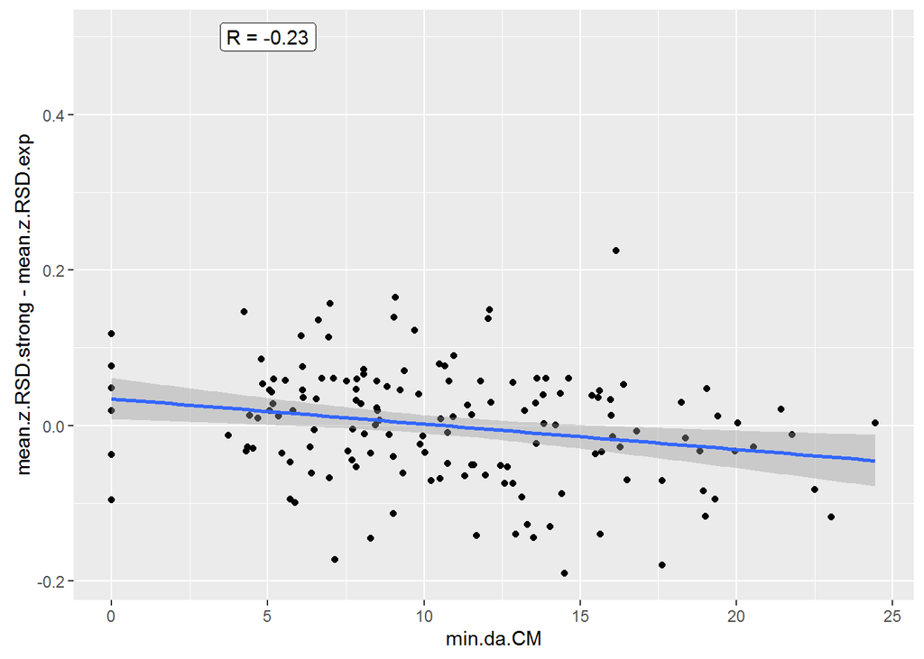

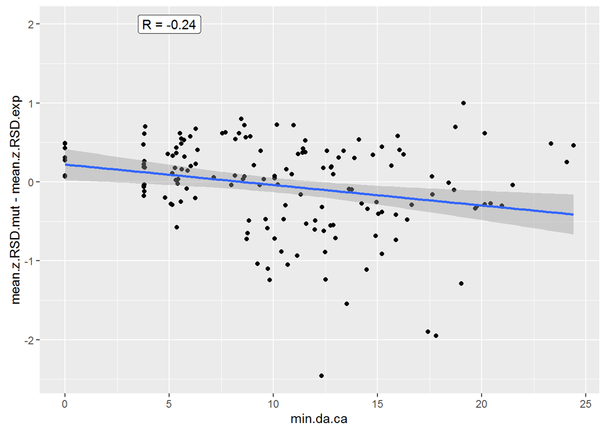

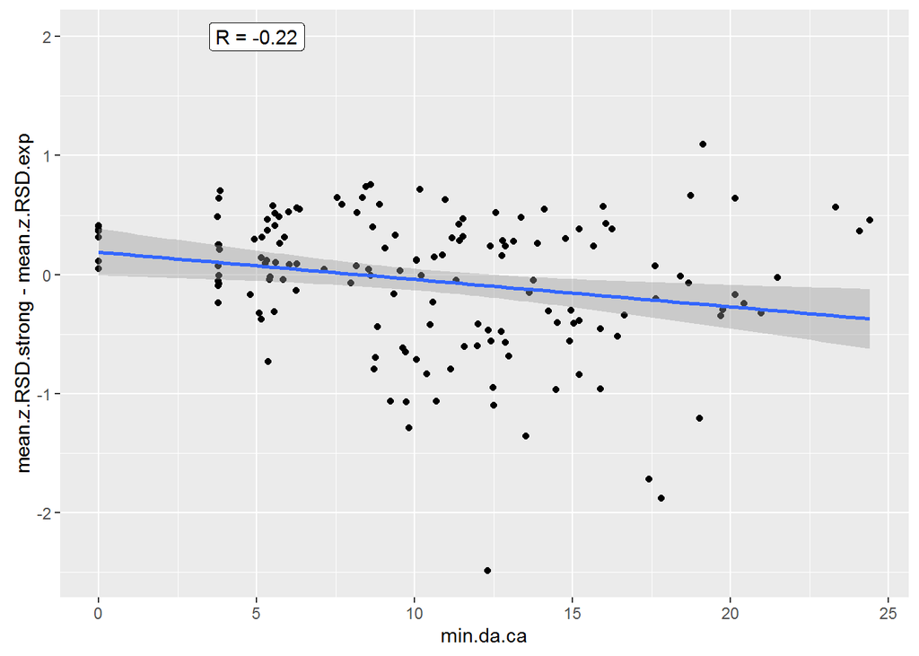

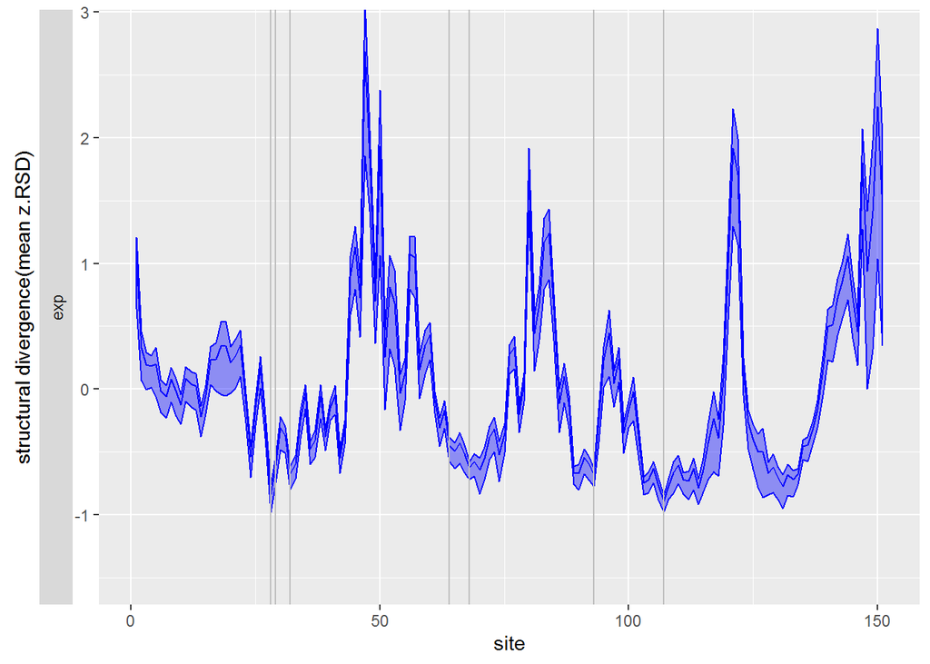

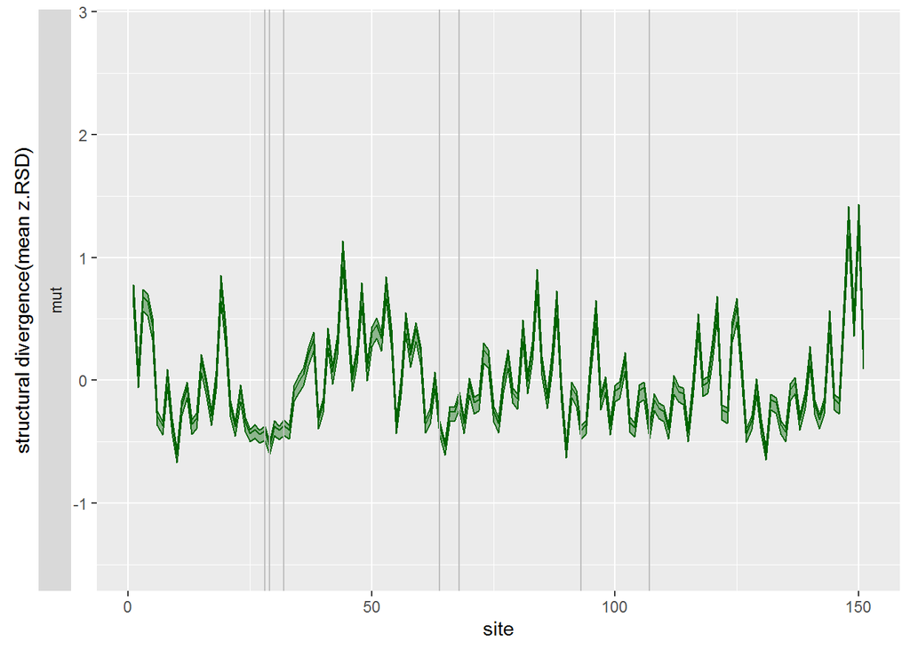

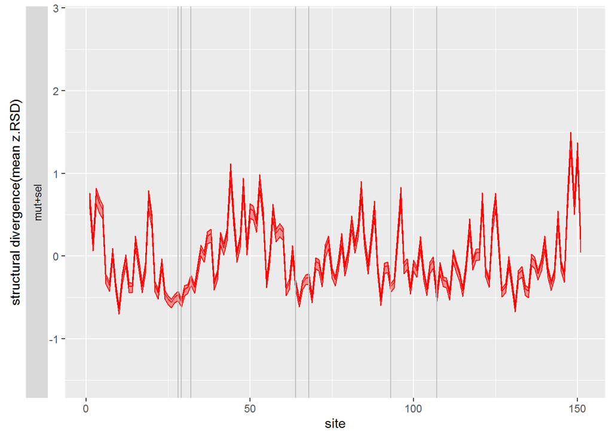

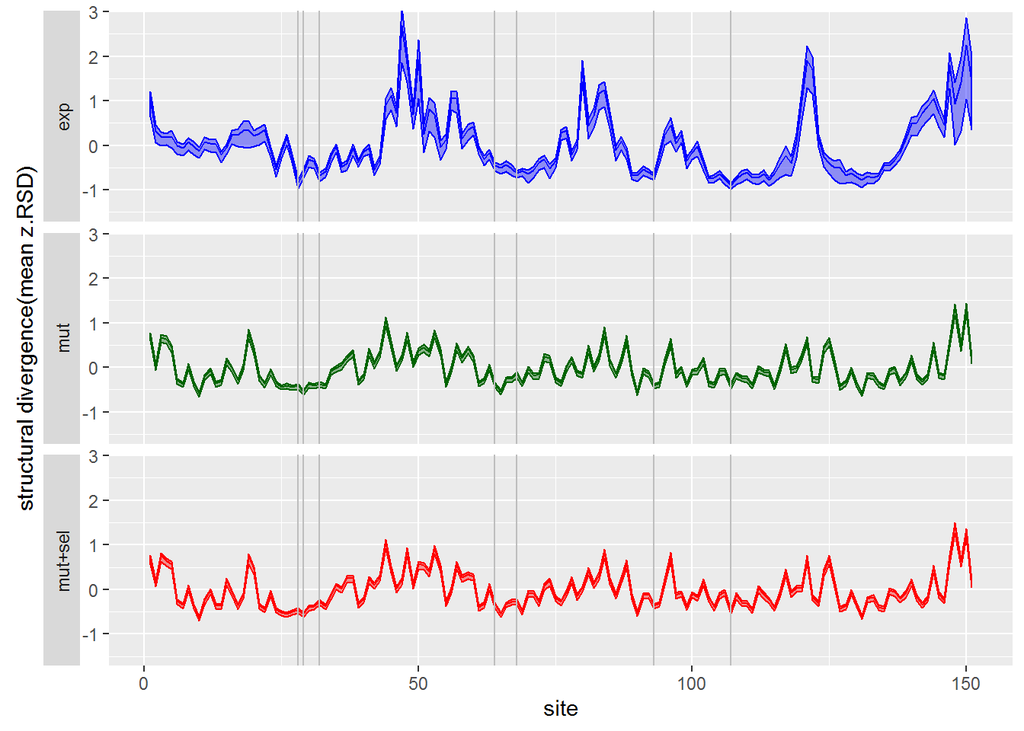

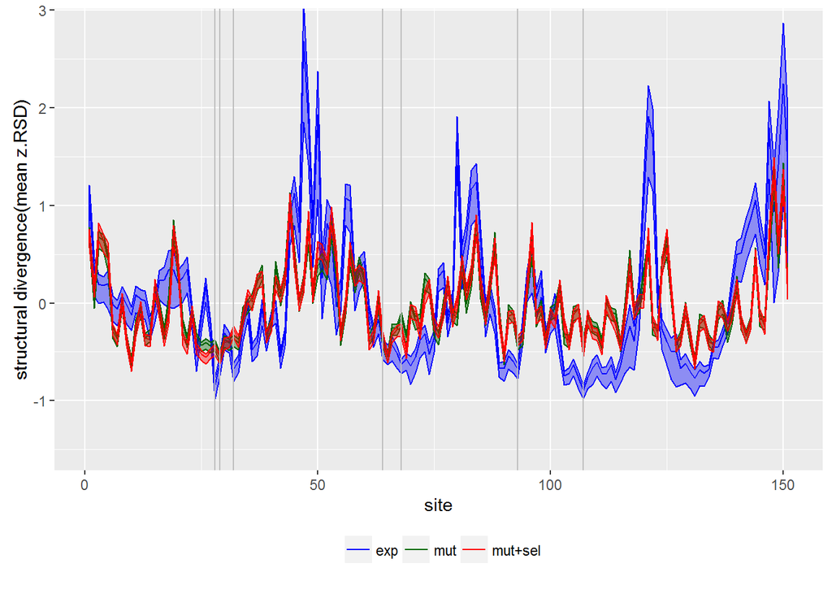

VAL107 and its neighbors (including site 32) are more structurally conserved than predicted.

### Correlation between site profiles

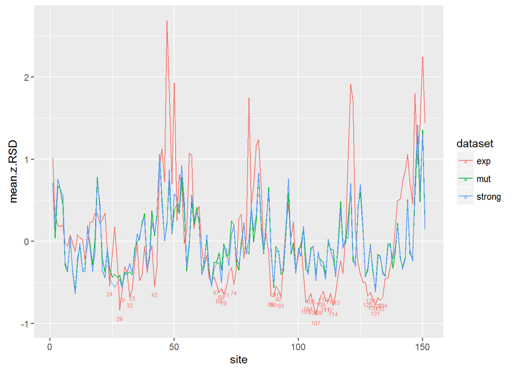

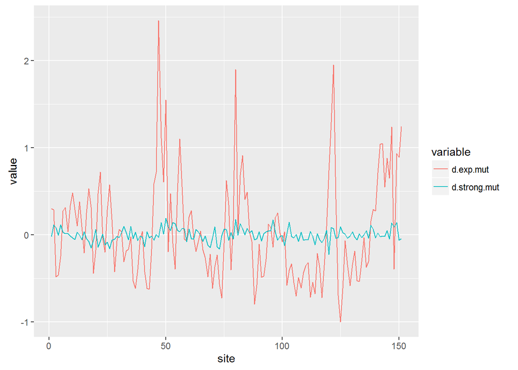

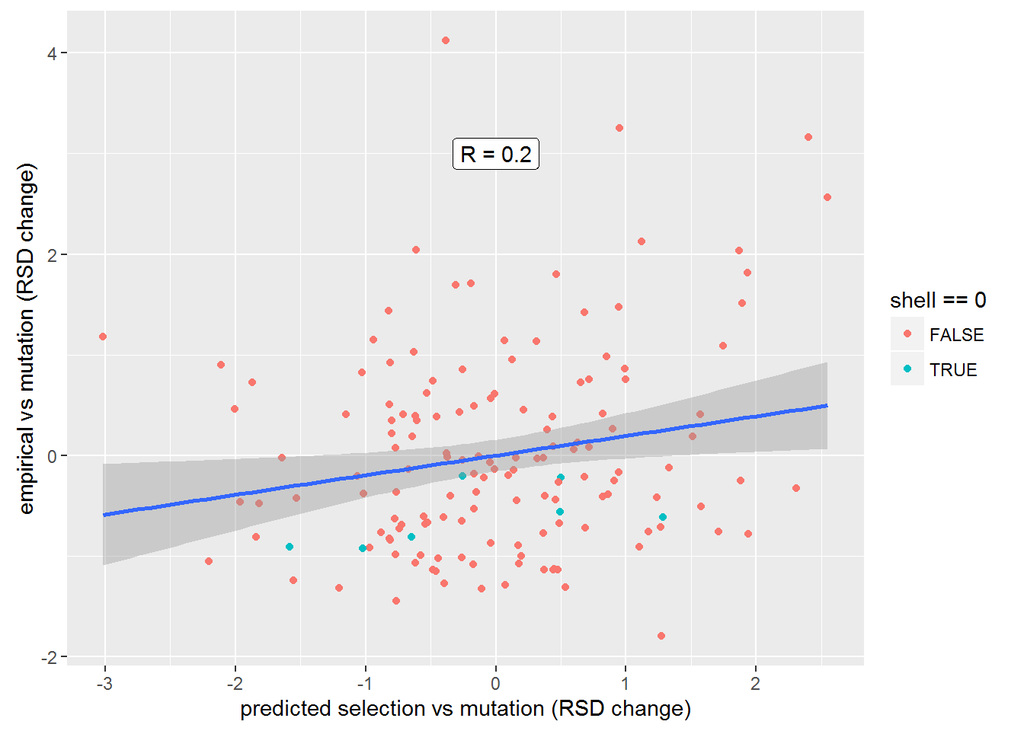

| comparison | R |
| --- | --- |
| exp vs mut | 0.57 |
| exp vs strong | 0.59 |
| mut vs strong | 0.98 |

# Structural divergence along normal modes

In this section we consider structural divergence using normal mode coordinates. Pn is the square divergence along a normal mode relative to the mean.

### Pn vs. mode energy

Note: lines are the median, 0.05 and 0.95 quantiles fit using rq(Pn ~ sn2). sn2 = 1/energy is the expected MSD of along mode n. The mean value of Pn should be a linear function of sn2 (Pn is normalized, sn2 is not).

Here we show the square deviation along each normal mode (normalized so that = 1) vs. the normal-mode’s energy. For the empirical data, we use the actual energy obtained from Keff for the given comparison. It is this energy the one that should be used, since it’s inverse is the expected value of Pn. Lines are the .5 (median), .05, and .95 quantiles obtained using `rq()` - Upper panel: simulated vs empirical data, shown separately. - Lower panel: simulated vs empirical overlaped and zoomed to better see the pattern.

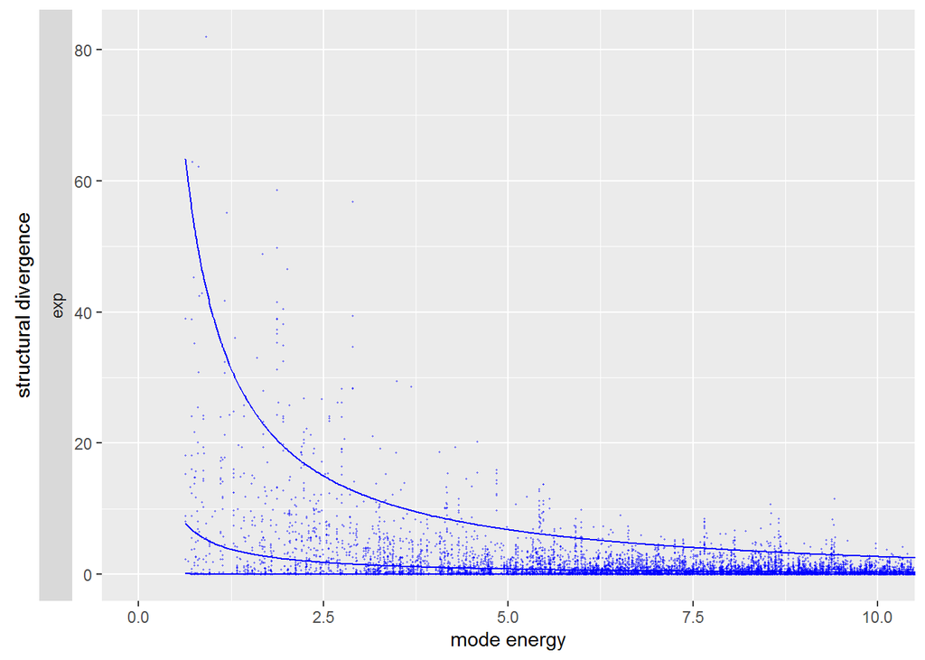

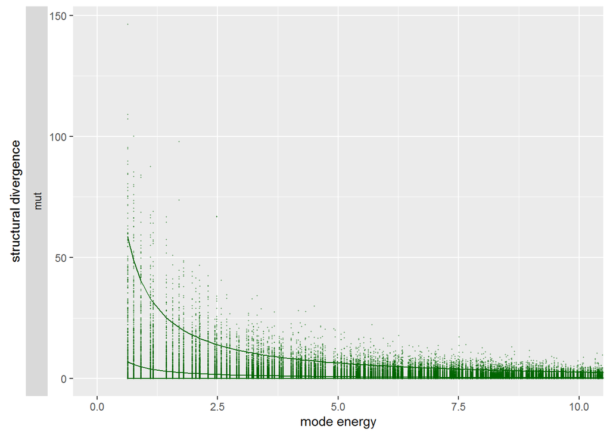

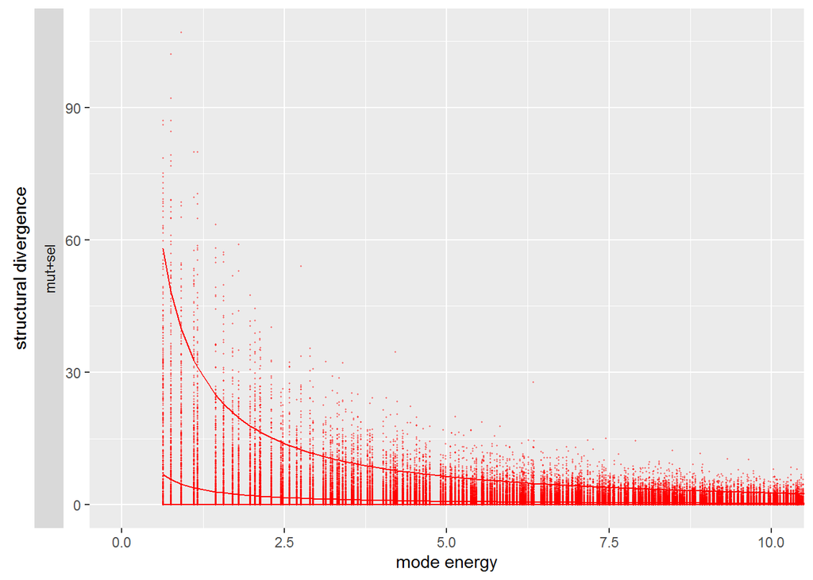

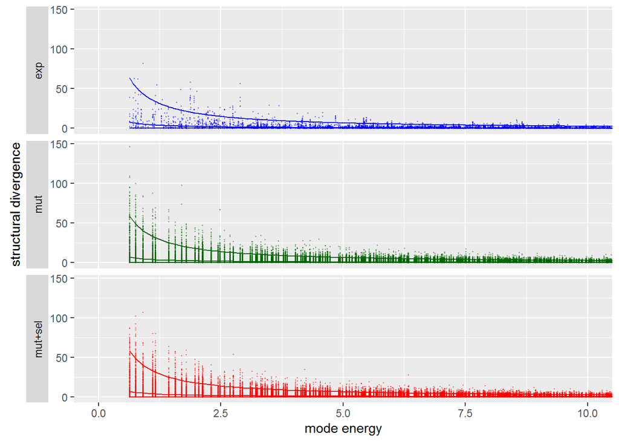

### median(Pn) vs mode energy

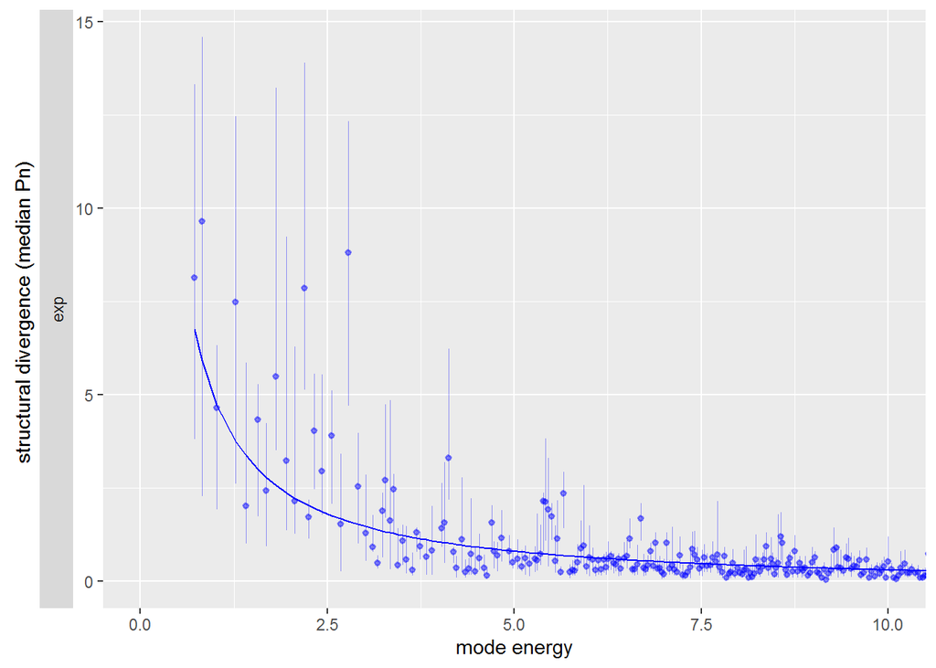

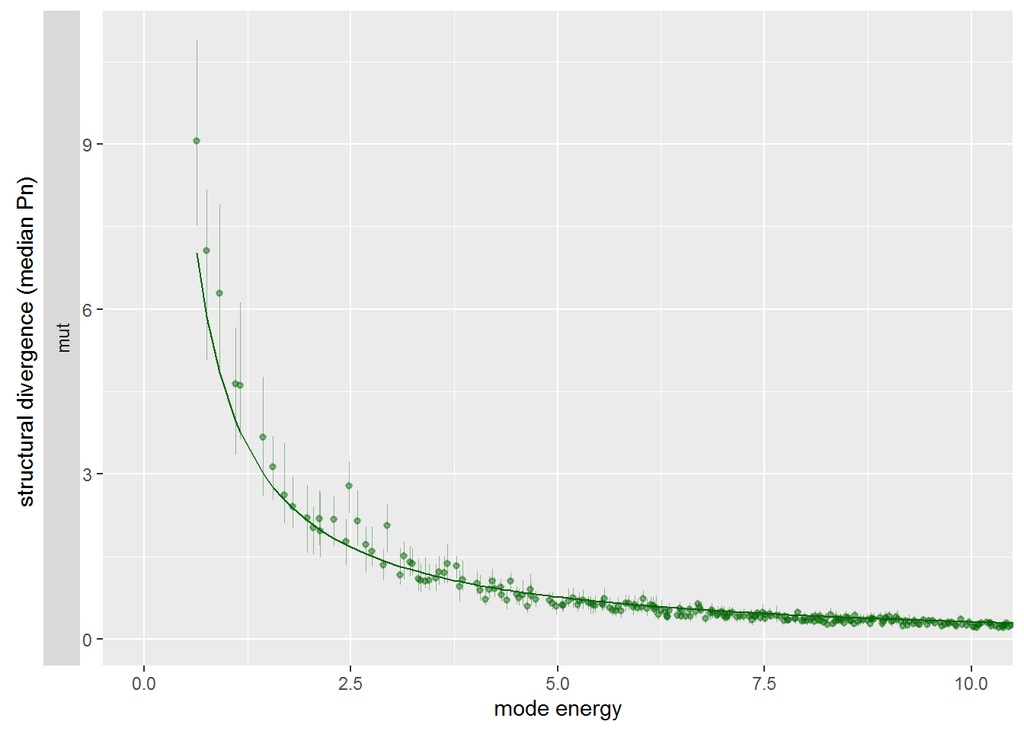

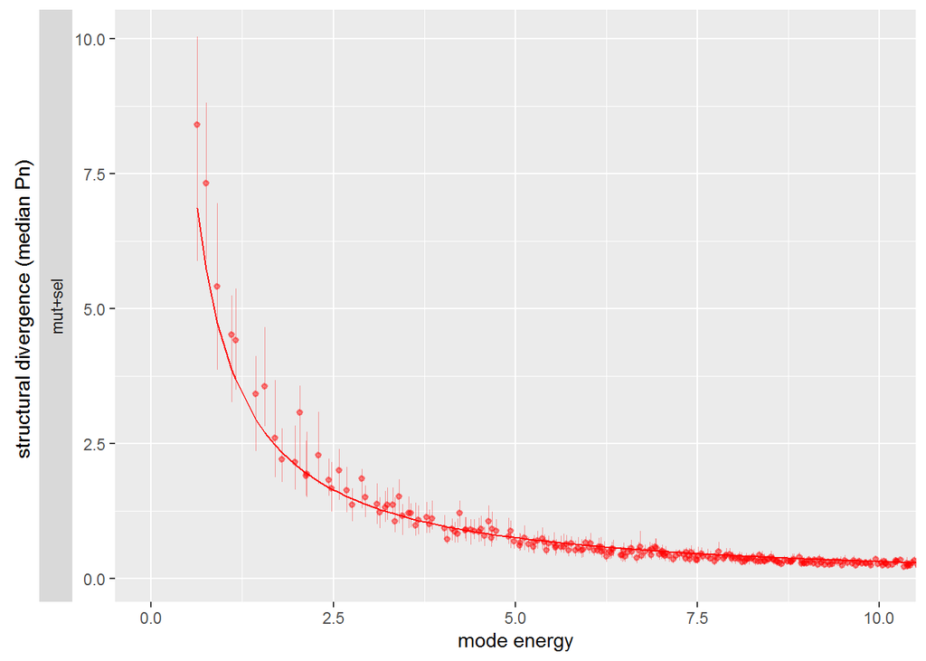

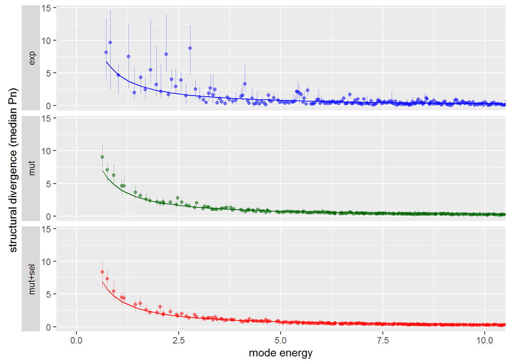

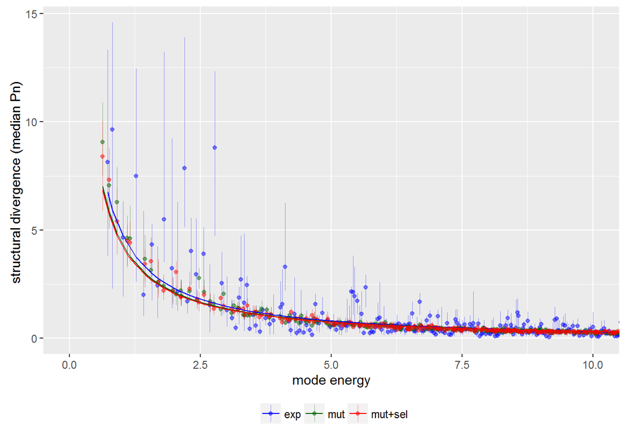

### Correlation between mode profiles

| comparison | R |
| --- | --- |
| exp vs mut | 0.77 |
| exp vs strong | 0.80 |
| mut vs strong | 0.98 |